# Code for STA 640 final project

Juan Pablo López Escamilla

2026-04-23

# Read data and quick EDA

The data was obtain from Kaggle. The treatment variables are Tech.Support and Discount, the outcome is Revenue, and the other variables will be used as covariates.

```r
df <- read.csv("https://raw.githubusercontent.com/JP-LopezEsc/sta640_causal_inference_project/main/data/multi_attribution_sample.csv")
head(df)
```

```
##   Global.Flag Major.Flag SMC.Flag Commercial.Flag IT.Spend Employee.Count
## 1           1          0        1               0    45537             26
## 2           0          0        1               1    20842            107
## 3           0          0        0               1    82171             10
## 4           0          0        0               0    30288             40
## 5           0          0        1               0    25930             37
## 6           0          0        1               0    34597             44
##   PC.Count   Size Tech.Support Discount  Revenue
## 1       26 152205            0        1 17688.36
## 2       70 159038            0        1 14981.44
## 3        7 264935            1        1 32917.14
## 4       39  77522            1        1 14773.77
## 5       43  91446            1        1 17098.70
## 6       51 218703            1        0 17280.71
```

```r
summary(df)
```

```
##   Global.Flag      Major.Flag       SMC.Flag      Commercial.Flag
##  Min.   :0.000   Min.   :0.000   Min.   :0.0000   Min.   :0.000
##  1st Qu.:0.000   1st Qu.:0.000   1st Qu.:0.0000   1st Qu.:0.000
##  Median :0.000   Median :0.000   Median :1.0000   Median :1.000
##  Mean   :0.202   Mean   :0.195   Mean   :0.5045   Mean   :0.691
##  3rd Qu.:0.000   3rd Qu.:0.000   3rd Qu.:1.0000   3rd Qu.:1.000
##  Max.   :1.000   Max.   :1.000   Max.   :1.0000   Max.   :1.000
##     IT.Spend      Employee.Count      PC.Count           Size
##  Min.   :  1161   Min.   : 10.00   Min.   :  6.00   Min.   : 10101
##  1st Qu.:  8914   1st Qu.: 24.00   1st Qu.: 22.00   1st Qu.: 39282
##  Median : 19210   Median : 44.00   Median : 41.00   Median : 81378
##  Mean   : 28273   Mean   : 61.12   Mean   : 57.35   Mean   :113159
##  3rd Qu.: 37992   3rd Qu.: 79.00   3rd Qu.: 74.00   3rd Qu.:155635
##  Max.   :259808   Max.   :535.00   Max.   :407.00   Max.   :766485
##   Tech.Support      Discount         Revenue
##  Min.   :0.000   Min.   :0.0000   Min.   : -616.6
##  1st Qu.:0.000   1st Qu.:0.0000   1st Qu.: 7545.1
##  Median :1.000   Median :1.0000   Median :12582.4
##  Mean   :0.503   Mean   :0.5105   Mean   :15397.9
##  3rd Qu.:1.000   3rd Qu.:1.0000   3rd Qu.:19663.0
##  Max.   :1.000   Max.   :1.0000   Max.   :86006.9
```

```r
colSums(is.na(df)) # no missing values
```

```
##     Global.Flag      Major.Flag        SMC.Flag Commercial.Flag        IT.Spend
##               0               0               0               0               0
##  Employee.Count        PC.Count            Size    Tech.Support        Discount
##               0               0               0               0               0
##         Revenue
##               0
```

We have around 500 observations for each of the 4 different treatment combinations:

```r
sum(df$Tech.Support)
```

```
## [1] 1006
```

```r
sum(df$Discount)
```

```
## [1] 1021
```

```r
table(df[c('Tech.Support', 'Discount')])
```

```
##             Discount
## Tech.Support   0   1
##            0 517 477
##            1 462 544
```

There is a clear association between both treatments and the revenue:

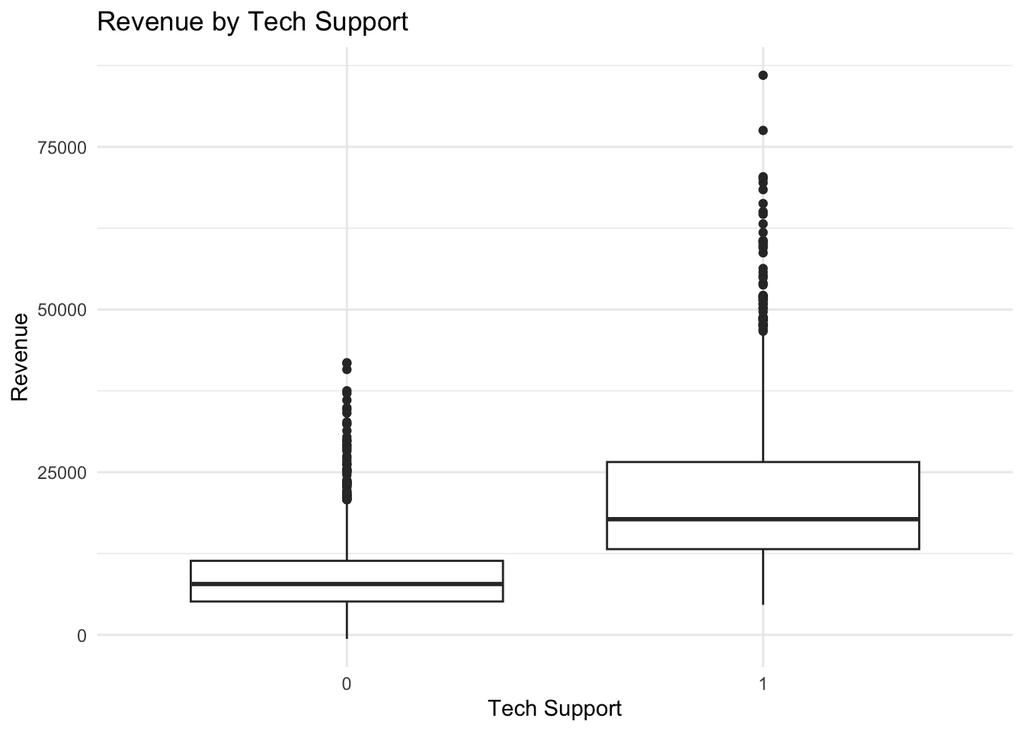

```r
# Boxplot: Tech Support vs Revenue
ggplot(df, aes(x = factor(Tech.Support), y = Revenue)) +
  geom_boxplot() +
  labs(x = "Tech Support", y = "Revenue",
       title = "Revenue by Tech Support") +
  theme_minimal()
```

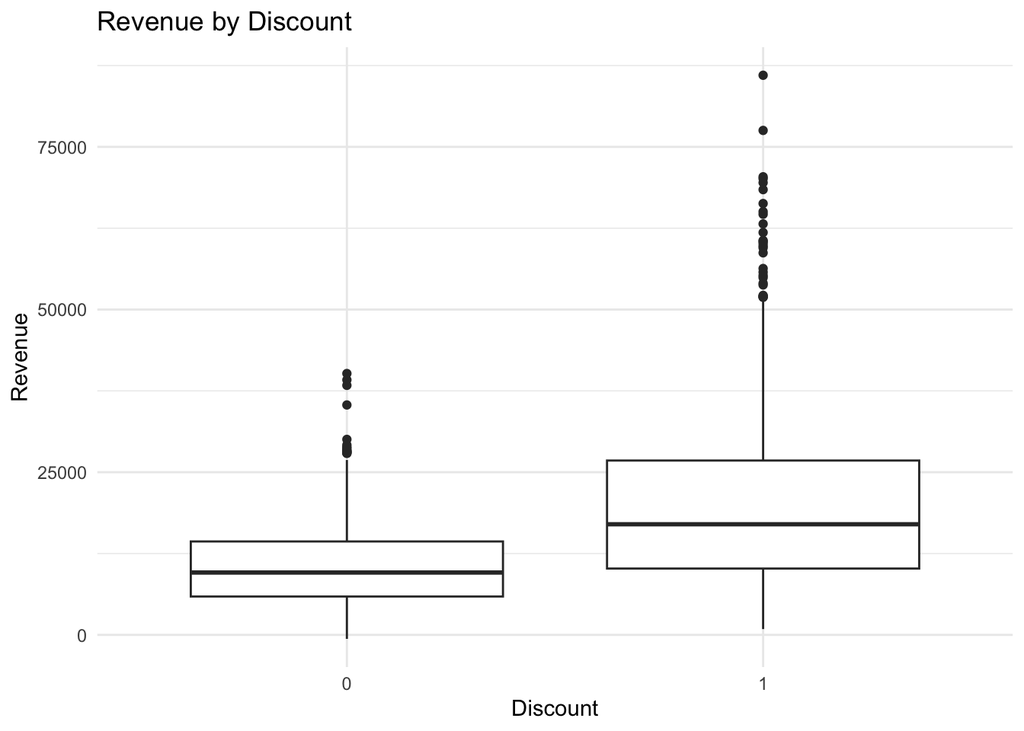

```r
# Boxplot: Discount vs Revenue
ggplot(df, aes(x = factor(Discount), y = Revenue)) +
  geom_boxplot() +
  labs(x = "Discount", y = "Revenue",
       title = "Revenue by Discount") +
  theme_minimal()
```

Revenue difference under different treatment settings (THIS IS NOT A CAUSAL EFFECT):

```r
mean(df$Revenue[df$Tech.Support == 1 & df$Discount == 1]) -
  mean(df$Revenue[df$Tech.Support == 0 & df$Discount == 0])
```

```
## [1] 20198.23
```

If the treatment assignment was randomized, we could conclude that the ATE between receiving both treatments and no treatment is $20198. However, the treatment assignment may not be randomized, so we need to use other techniques to estimate the causal effects.

## Propensity score

### Overlap and balance check

First, we estimate the propensity scores for each treatment combination using a multinomial logistic regression model. We then assess the overlap assumption by comparing the density distributions of the estimated propensity scores across the four treatment combinations. After that, we check covariate balance

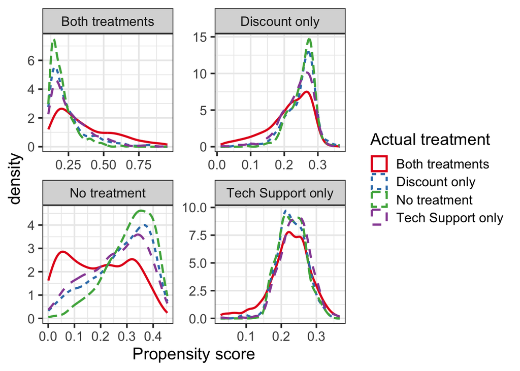

```r
library(PSweight)

# Combine two binary treatments into one factor with 4 levels
df$trt <- ifelse(df$Tech.Support == 0 & df$Discount == 0, 'No treatment',
                 ifelse(df$Tech.Support == 1 & df$Discount == 0, "Tech Support only",
                        ifelse(df$Tech.Support == 0 & df$Discount == 1, "Discount only",
                               "Both treatments")))

# Define propensity score formula
ps_formula <- trt ~ Global.Flag + Major.Flag + SMC.Flag + Commercial.Flag +
                    IT.Spend + Employee.Count + PC.Count + Size

# Fit a multinomial logistic regression
balance_ps <- SumStat(ps.formula = ps_formula,
                      weight = c('IPW','overlap','treated'),
                      data = df)

ps_df <- as.data.frame(balance_ps$propensity)
ps_df$actual_trt <- df$trt

ps_long <- as.data.frame(balance_ps$propensity) |>
  mutate(actual_trt = df$trt) |>
  pivot_longer(-actual_trt,
               names_to = "ps_group",
               values_to = "ps")

ggplot(ps_long,
       aes(x = ps, color = actual_trt, linetype = actual_trt)) +
  geom_density(size = 1) +
  facet_wrap(~ps_group, scales = "free") +
  scale_color_brewer(palette = "Set1") +
  theme_bw(base_size = 16) +
  labs(
    x = "Propensity score",
    color = "Actual treatment",
    linetype = "Actual treatment"
  )
```

Checking covariance balance using ASD, we see that size and IT spend were particularly unbalanced before the weighting. All weighting methods are succesful to balance all the covariates.

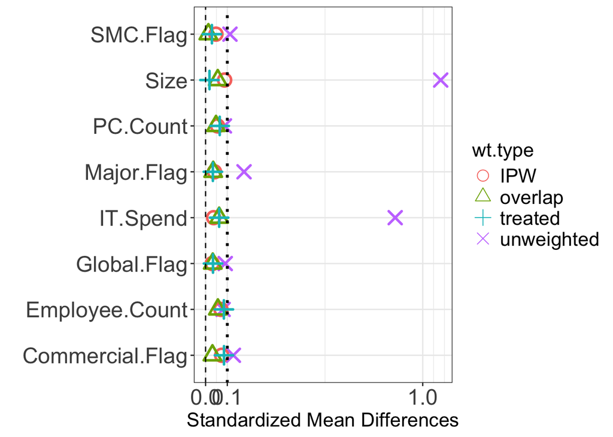

```r
plot(balance_ps, type = "balance", metric = "ASD")
```

In the following plots it is clear that the company tends to apply both treatments to companies that have bigger size and IT spend, which means they may have a strategy of allocating more efforts to larger companies:

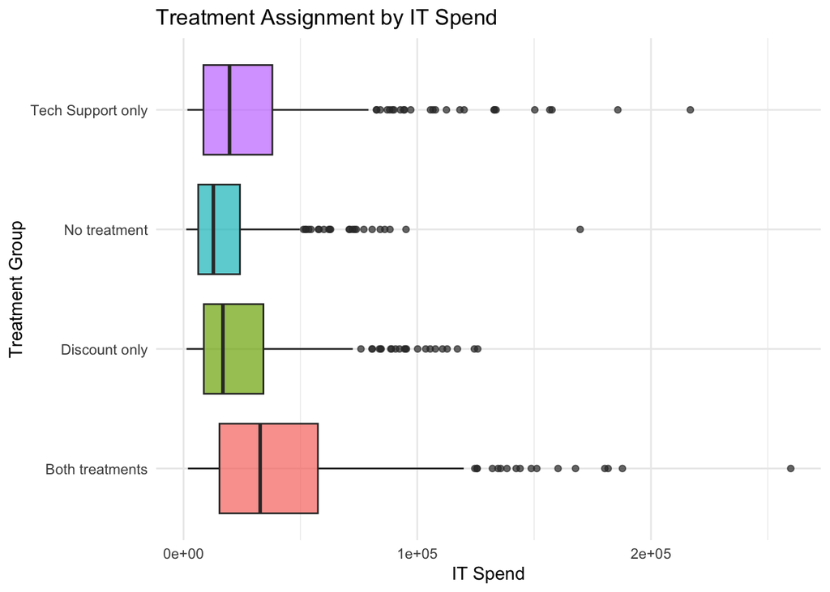

```r
ggplot(df, aes(x = IT.Spend, y = trt, fill = trt)) +
  geom_boxplot(alpha = 0.7) +
  theme_minimal() +
  labs(title = "Treatment Assignment by IT Spend",
       x = "IT Spend",
       y = "Treatment Group") +
  theme(legend.position = "none")
```

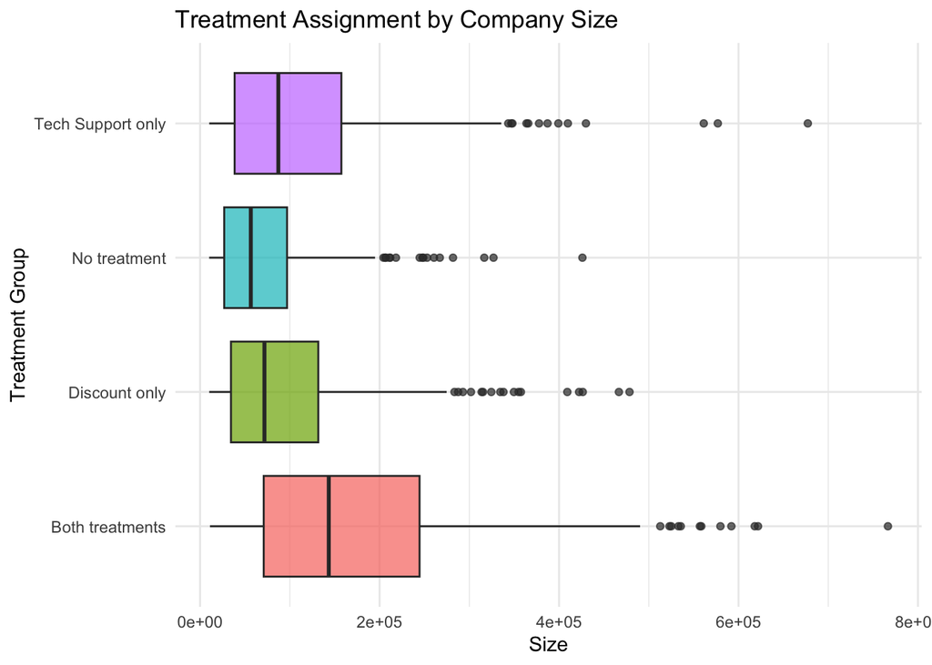

```r
ggplot(df, aes(x = Size, y = trt, fill = trt)) +
  geom_boxplot(alpha = 0.7) +
  theme_minimal() +
  labs(title = "Treatment Assignment by Company Size",
       x = "Size",
       y = "Treatment Group") +
  theme(legend.position = "none")
```

Since the four treatment groups are not comparable, we apply different weighting mechanisms to balance the covariates in the following sections.

### Overlap weights

```r
set.seed(0)
ate_overlap <- PSweight(ps.formula = ps_formula,
                         yname = "Revenue",
                         data = df,
                         weight = 'overlap',
                         bootstrap = TRUE,
                         R=100)
```

```
## bootstrap 50 samples
```

```
## bootstrap 100 samples
```

```r
contrasts <- rbind(c(1,-1,0,0),c(1,0,-1,0),c(1,0,0,-1),c(0,1,-1,0),
                        c(0,1,0,-1),c(0,0,-1,1))

summary(ate_overlap, contrast = contrasts)
```

```
##
## Use Bootstrap sample for inference:
##
## Original group value:  Both treatments, Discount only, No treatment, Tech Support only
##
## Contrast:
##            Both treatments Discount only No treatment Tech Support only
## Contrast 1               1            -1            0                 0
## Contrast 2               1             0           -1                 0
## Contrast 3               1             0            0                -1
## Contrast 4               0             1           -1                 0
## Contrast 5               0             1            0                -1
## Contrast 6               0             0           -1                 1
##
##            Estimate Std.Error      lwr     upr  Pr(>|z|)
## Contrast 1  7073.33    238.33  6627.48  7506.8 < 2.2e-16 ***
## Contrast 2 12066.75    255.03 11506.76 12492.9 < 2.2e-16 ***
## Contrast 3  5050.75    256.38  4538.97  5485.1 < 2.2e-16 ***
## Contrast 4  4993.42    183.88  4599.99  5343.1 < 2.2e-16 ***
## Contrast 5 -2022.58    144.02 -2300.38 -1734.0 < 2.2e-16 ***
## Contrast 6  7016.00    117.79  6771.45  7215.8 < 2.2e-16 ***
## ---
## Signif. codes:  0 '***' 0.001 '**' 0.01 '*' 0.05 '.' 0.1 ' ' 1
```

### IPW

```r
ate_ipw <- PSweight(ps.formula = ps_formula,
                         yname = "Revenue",
                         data = df,
                         weight = 'IPW',
                         bootstrap = TRUE,
                         R=100)
```

```
## bootstrap 50 samples
```

```
## bootstrap 100 samples
```

```r
summary(ate_ipw, contrast = contrasts)
```

```
##
## Use Bootstrap sample for inference:
##
## Original group value:  Both treatments, Discount only, No treatment, Tech Support only
##
## Contrast:
##            Both treatments Discount only No treatment Tech Support only
## Contrast 1               1            -1            0                 0
## Contrast 2               1             0           -1                 0
## Contrast 3               1             0            0                -1
## Contrast 4               0             1           -1                 0
## Contrast 5               0             1            0                -1
## Contrast 6               0             0           -1                 1
##
##            Estimate Std.Error      lwr      upr  Pr(>|z|)
## Contrast 1  7199.76    316.66  6464.38  7750.44 < 2.2e-16 ***
## Contrast 2 13405.60    403.30 12578.60 14022.64 < 2.2e-16 ***
## Contrast 3  5664.79    324.96  5165.57  6302.42 < 2.2e-16 ***
## Contrast 4  6205.83    491.39  5257.82  7114.69 < 2.2e-16 ***
## Contrast 5 -1534.97    472.81 -2268.36  -476.41 < 2.2e-16 ***
## Contrast 6  7740.80    496.43  6641.52  8547.52 < 2.2e-16 ***
## ---
## Signif. codes:  0 '***' 0.001 '**' 0.01 '*' 0.05 '.' 0.1 ' ' 1
```

### ATT

```r
ate_treated <- PSweight(ps.formula = ps_formula,
                         yname = "Revenue",
                         data = df,
                         weight = 'treated',
                         bootstrap = TRUE,
                         R=100)
```

```
## bootstrap 50 samples
```

```
## bootstrap 100 samples
```

```r
summary(ate_treated, contrast = contrasts)
```

```
##
## Use Bootstrap sample for inference:
##
## Original group value:  Both treatments, Discount only, No treatment, Tech Support only
## Treatment group value:  Tech Support only
##
## Contrast:
##            Both treatments Discount only No treatment Tech Support only
## Contrast 1               1            -1            0                 0
## Contrast 2               1             0           -1                 0
## Contrast 3               1             0            0                -1
## Contrast 4               0             1           -1                 0
## Contrast 5               0             1            0                -1
## Contrast 6               0             0           -1                 1
##
##            Estimate Std.Error      lwr      upr  Pr(>|z|)
## Contrast 1  7166.72    298.67  6504.19  7682.54 < 2.2e-16 ***
## Contrast 2 12785.37    465.34 11950.62 13590.02 < 2.2e-16 ***
## Contrast 3  5568.17    323.57  4849.12  6064.08 < 2.2e-16 ***
## Contrast 4  5618.65    454.02  4953.81  6624.21 < 2.2e-16 ***
## Contrast 5 -1598.54    278.60 -2057.72  -934.92 < 2.2e-16 ***
## Contrast 6  7217.20    276.92  6672.65  7726.81 < 2.2e-16 ***
## ---
## Signif. codes:  0 '***' 0.001 '**' 0.01 '*' 0.05 '.' 0.1 ' ' 1
```

### Doubly robust (DR)

```r
out_formula <- Revenue ~ Global.Flag + Major.Flag + SMC.Flag + Commercial.Flag +
                    IT.Spend + Employee.Count + PC.Count + Size
ate_dr <- PSweight(ps.formula = ps_formula,
                        out.formula = out_formula,
                         yname = "Revenue",
                         data = df,
                         weight = 'IPW',
                         augmentation = TRUE,
                         bootstrap = TRUE,
                         R=100)
```

```
## bootstrap 50 samples
```

```
## bootstrap 100 samples
```

```r
summary(ate_dr, contrast = contrasts)
```

```
##
## Use Bootstrap sample for inference:
##
## Original group value:  Both treatments, Discount only, No treatment, Tech Support only
##
## Contrast:
##            Both treatments Discount only No treatment Tech Support only
## Contrast 1               1            -1            0                 0
## Contrast 2               1             0           -1                 0
## Contrast 3               1             0            0                -1
## Contrast 4               0             1           -1                 0
## Contrast 5               0             1            0                -1
## Contrast 6               0             0           -1                 1
##
##             Estimate Std.Error       lwr     upr  Pr(>|z|)
## Contrast 1  7142.889    84.506  6946.372  7291.8 < 2.2e-16 ***
## Contrast 2 12917.684   189.908 12542.922 13242.1 < 2.2e-16 ***
## Contrast 3  5615.325   126.342  5368.349  5834.3 < 2.2e-16 ***
## Contrast 4  5774.795   145.607  5490.808  6058.1 < 2.2e-16 ***
## Contrast 5 -1527.564    84.478 -1709.608 -1379.4 < 2.2e-16 ***
## Contrast 6  7302.358   110.149  7052.162  7494.7 < 2.2e-16 ***
## ---
## Signif. codes:  0 '***' 0.001 '**' 0.01 '*' 0.05 '.' 0.1 ' ' 1
```

## Optimal trimming

Trimming is important because in the propensity scores overlap plot it is clear that some propensity scores are extremely small, so the IPW weights will be extreme as well. We apply optimal trimming and show how many units remain after trimming.

```r
opt_trim <- PStrim(ps.formula = ps_formula, data = df, optimal = TRUE)
opt_trim$trim_sum
```

```
##          Both treatments Discount only No treatment Tech Support only
## trimmed               73            12            3                11
## remained             471           465          514               451
```

The covariates are balanced, and the propensity scores are less extreme after trimming.

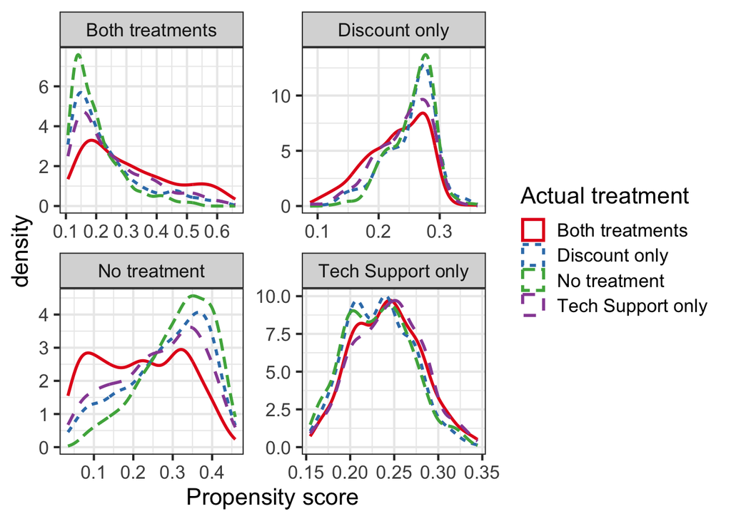

```r
# trimmed data
opt_trim_df <- opt_trim$data

#Check the overlap
balance_trim <- SumStat(ps.formula = ps_formula,
                             weight = c('IPW','overlap','treated'),
                             data = opt_trim_df)

ps_long_trim <- as.data.frame(balance_trim$propensity) |>
  mutate(actual_trt = opt_trim_df$trt) |>
  pivot_longer(-actual_trt,
               names_to = "ps_group",
               values_to = "ps")

ggplot(ps_long_trim,
       aes(x = ps, color = actual_trt, linetype = actual_trt)) +
  geom_density(size = 1) +
  facet_wrap(~ps_group, scales = "free") +
  scale_color_brewer(palette = "Set1") +
  theme_bw(base_size = 16) +
  labs(
    x = "Propensity score",
    color = "Actual treatment",
    linetype = "Actual treatment"
  )
```

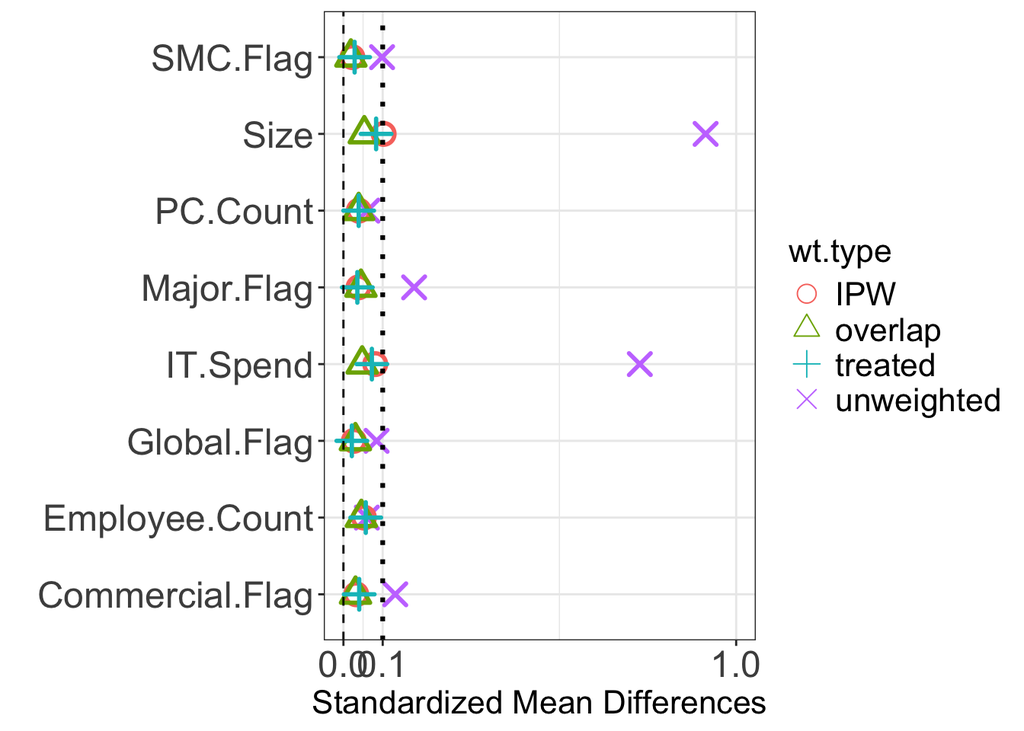

```r
#Covariates balance after trimming
plot(balance_trim, type = "balance", metric = "ASD")
```

With this trimmed data we can re-estimate the causal effects with IPW.

### Trimmed IPW

```r
ate_ipw_trim <- PSweight(ps.formula = ps_formula,
                         yname = "Revenue",
                         data = opt_trim_df,
                         weight = 'IPW',
                         bootstrap = TRUE,
                         R=100)
```

```
## bootstrap 50 samples
```

```
## bootstrap 100 samples
```

```r
summary(ate_ipw_trim, contrast = contrasts)
```

```
##
## Use Bootstrap sample for inference:
##
## Original group value:  Both treatments, Discount only, No treatment, Tech Support only
##
## Contrast:
##            Both treatments Discount only No treatment Tech Support only
## Contrast 1               1            -1            0                 0
## Contrast 2               1             0           -1                 0
## Contrast 3               1             0            0                -1
## Contrast 4               0             1           -1                 0
## Contrast 5               0             1            0                -1
## Contrast 6               0             0           -1                 1
##
##            Estimate Std.Error      lwr     upr  Pr(>|z|)
## Contrast 1  6908.40    209.06  6462.82  7269.1 < 2.2e-16 ***
## Contrast 2 12222.98    219.14 11838.74 12628.8 < 2.2e-16 ***
## Contrast 3  5041.97    191.80  4692.02  5409.0 < 2.2e-16 ***
## Contrast 4  5314.58    226.46  4917.59  5755.9 < 2.2e-16 ***
## Contrast 5 -1866.43    188.09 -2200.67 -1461.6 < 2.2e-16 ***
## Contrast 6  7181.01    131.41  6874.88  7402.0 < 2.2e-16 ***
## ---
## Signif. codes:  0 '***' 0.001 '**' 0.01 '*' 0.05 '.' 0.1 ' ' 1
```

### Trimmed Doubly robust (DR)

```r
ate_dr_trim <- PSweight(ps.formula = ps_formula,
                        out.formula = out_formula,
                         yname = "Revenue",
                         data = opt_trim_df,
                         weight = 'IPW',
                         augmentation = TRUE,
                         bootstrap = TRUE,
                         R=100)
```

```
## bootstrap 50 samples
```

```
## bootstrap 100 samples
```

```r
summary(ate_dr_trim, contrast = contrasts)
```

```
##
## Use Bootstrap sample for inference:
##
## Original group value:  Both treatments, Discount only, No treatment, Tech Support only
##
## Contrast:
##            Both treatments Discount only No treatment Tech Support only
## Contrast 1               1            -1            0                 0
## Contrast 2               1             0           -1                 0
## Contrast 3               1             0            0                -1
## Contrast 4               0             1           -1                 0
## Contrast 5               0             1            0                -1
## Contrast 6               0             0           -1                 1
##
##             Estimate Std.Error       lwr     upr  Pr(>|z|)
## Contrast 1  6847.508    84.081  6687.350  7006.1 < 2.2e-16 ***
## Contrast 2 11810.438   134.872 11534.243 12068.9 < 2.2e-16 ***
## Contrast 3  4870.733   115.565  4662.088  5091.0 < 2.2e-16 ***
## Contrast 4  4962.930    96.965  4776.014  5143.7 < 2.2e-16 ***
## Contrast 5 -1976.774    87.141 -2142.329 -1810.7 < 2.2e-16 ***
## Contrast 6  6939.705    74.880  6808.293  7102.3 < 2.2e-16 ***
## ---
## Signif. codes:  0 '***' 0.001 '**' 0.01 '*' 0.05 '.' 0.1 ' ' 1
```

## Tables

Create tables to sumarize the results from the code above:

```r
contrast_names <- paste0("Contrast ", 1:6)

# extract function
extract_psw <- function(model, method_name, contrasts, trimmed = FALSE) {
  s <- summary(model, contrast = contrasts)

  tab <- as.data.frame(s$estimates)

  tab$Method <- method_name
  tab$Trimmed <- if (trimmed) "Trimmed" else "Untrimmed"
  tab$Contrast <- rownames(tab)

  rownames(tab) <- NULL
  tab
}


# build full results table
all_results <- rbind(

  # ---------------- untrimmed ----------------
  extract_psw(ate_ipw, "IPW", contrasts, FALSE),
  extract_psw(ate_overlap, "Overlap", contrasts, FALSE),
  extract_psw(ate_treated, "ATT", contrasts, FALSE),
  extract_psw(ate_dr, "DR", contrasts, FALSE),

  # ---------------- trimmed ----------------
  extract_psw(ate_ipw_trim, "IPW", contrasts, TRUE),
  extract_psw(ate_dr_trim, "DR", contrasts, TRUE)
)
```

```r
# Keep only relevant columns
all_results <- all_results[, c(
  "Contrast", "Method", "Trimmed",
  "Estimate", "Std.Error",
  "lwr", "upr", "Pr(>|z|)"
)]


# Ordering
method_order <- c("IPW", "Overlap", "ATT", "DR")
trim_order <- c("Untrimmed", "Trimmed")

all_results$Method <- factor(all_results$Method, levels = method_order)
all_results$Trimmed <- factor(all_results$Trimmed, levels = trim_order)

all_results <- all_results %>%
  arrange(Contrast, Method, Trimmed)


# split into 6 tables
tables <- split(all_results, all_results$Contrast)

tables <- lapply(tables, function(df) {
  df %>%
    arrange(Method, Trimmed)
})

# Print tables
for (nm in names(tables)) {
  cat("\n\n====================\n", nm, "\n====================\n")
  print(tables[[nm]])
}
```

```
##
##
## ====================
##  Contrast 1
## ====================
##     Contrast  Method   Trimmed Estimate Std.Error      lwr      upr Pr(>|z|)
## 1 Contrast 1     IPW Untrimmed 7199.763 316.65691 6464.380 7750.443        0
## 2 Contrast 1     IPW   Trimmed 6908.398 209.05852 6462.817 7269.082        0
## 3 Contrast 1 Overlap Untrimmed 7073.329 238.32581 6627.479 7506.832        0
## 4 Contrast 1     ATT Untrimmed 7166.715 298.66661 6504.192 7682.537        0
## 5 Contrast 1      DR Untrimmed 7142.889  84.50564 6946.372 7291.773        0
## 6 Contrast 1      DR   Trimmed 6847.508  84.08135 6687.350 7006.075        0
##
##
## ====================
##  Contrast 2
## ====================
##     Contrast  Method   Trimmed Estimate Std.Error      lwr      upr Pr(>|z|)
## 1 Contrast 2     IPW Untrimmed 13405.60  403.2985 12578.60 14022.64        0
## 2 Contrast 2     IPW   Trimmed 12222.98  219.1379 11838.74 12628.81        0
## 3 Contrast 2 Overlap Untrimmed 12066.75  255.0292 11506.76 12492.92        0
## 4 Contrast 2     ATT Untrimmed 12785.37  465.3419 11950.62 13590.02        0
## 5 Contrast 2      DR Untrimmed 12917.68  189.9080 12542.92 13242.05        0
## 6 Contrast 2      DR   Trimmed 11810.44  134.8718 11534.24 12068.86        0
##
##
## ====================
##  Contrast 3
## ====================
##     Contrast  Method   Trimmed Estimate Std.Error      lwr      upr Pr(>|z|)
## 1 Contrast 3     IPW Untrimmed 5664.793  324.9582 5165.575 6302.417        0
## 2 Contrast 3     IPW   Trimmed 5041.965  191.8026 4692.016 5408.998        0
## 3 Contrast 3 Overlap Untrimmed 5050.754  256.3763 4538.969 5485.109        0
## 4 Contrast 3     ATT Untrimmed 5568.171  323.5715 4849.123 6064.082        0
## 5 Contrast 3      DR Untrimmed 5615.325  126.3421 5368.349 5834.277        0
## 6 Contrast 3      DR   Trimmed 4870.733  115.5655 4662.088 5090.976        0
##
##
## ====================
##  Contrast 4
```

[output cut: 24 more lines]

```
## 4        0
## 5        0
## 6        0
##
##
## ====================
##  Contrast 6
## ====================
##     Contrast  Method   Trimmed Estimate Std.Error      lwr      upr Pr(>|z|)
## 1 Contrast 6     IPW Untrimmed 7740.804 496.43173 6641.519 8547.515        0
## 2 Contrast 6     IPW   Trimmed 7181.014 131.41012 6874.878 7401.970        0
## 3 Contrast 6 Overlap Untrimmed 7016.000 117.78569 6771.449 7215.768        0
## 4 Contrast 6     ATT Untrimmed 7217.197 276.91785 6672.646 7726.808        0
## 5 Contrast 6      DR Untrimmed 7302.358 110.14872 7052.162 7494.731        0
## 6 Contrast 6      DR   Trimmed 6939.705  74.87986 6808.293 7102.270        0
```

# CATE

In order to fully exploit this data, it is necessary to estimate the conditional average treatment effect given the covariates, which would allow us to create strategies to target the companies that are expected to generate more revenue when we apply the treatments to them.

Since we have multiple treatments, we can apply a multi-arm/multi-outcome causal forest using the grf package.

```r
library(grf)
# W must be a factor
df$W <- as.factor(df$trt)
# Set "No treatment" as the reference level
df$W <- relevel(df$W, ref = "No treatment")

X <- as.matrix(df[, c("Global.Flag", "Major.Flag", "SMC.Flag", "Commercial.Flag",
                      "IT.Spend", "Employee.Count", "PC.Count", "Size")])

# Train the multi-arm forest
mc_forest <- multi_arm_causal_forest(X = X,
                                     Y = df$Revenue,
                                     W = df$W)

mc_pred <- predict(mc_forest, drop = TRUE)
tau_hat <- mc_pred$predictions
```

In the following plot, we can see that the CATE is quite heterogeneous; therefore, the same treatment can have a very different effect on revenue depending on the characteristics of the companies.

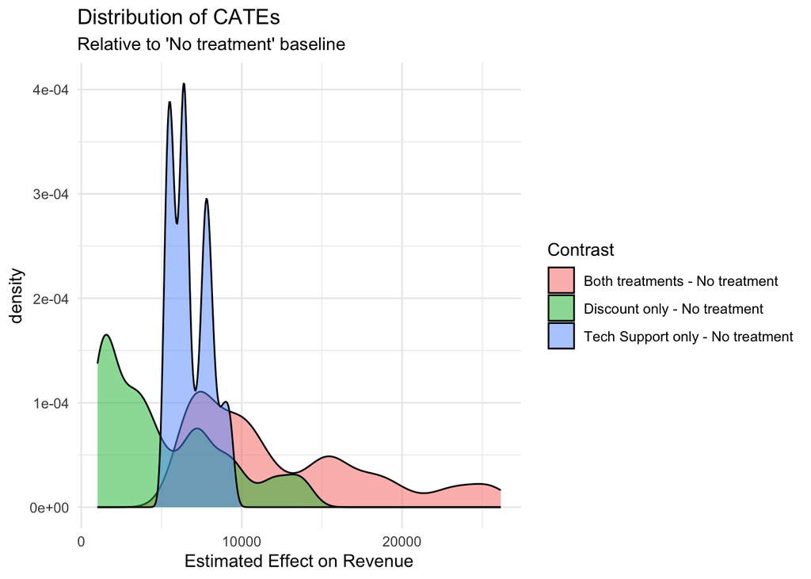

```r
df_tau <- as.data.frame(tau_hat)
df_tau_long <- df_tau %>%
  pivot_longer(everything(), names_to = "Contrast", values_to = "Effect")

ggplot(df_tau_long, aes(x = Effect, fill = Contrast)) +
  geom_density(alpha = 0.5) +
  theme_minimal() +
  labs(title = "Distribution of CATEs",
       subtitle = "Relative to 'No treatment' baseline",
       x = "Estimated Effect on Revenue")
```

Obtaining feature importance from the causal forest reveals that Size and IT.Spend are the most significant covariates. Notably, these two variables also exhibited the most imbalance across the treatment groups.

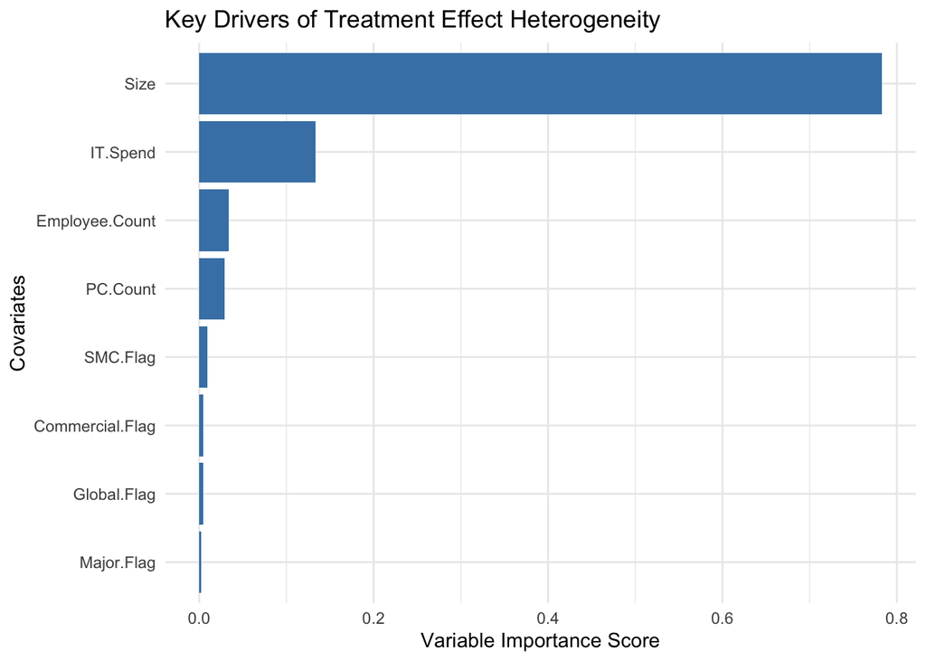

```r
vi <- variable_importance(mc_forest)
names(vi) <- colnames(X) # Ensure X is your covariate matrix

vi_df <- data.frame(Feature = names(vi), Importance = vi)
ggplot(vi_df, aes(x = reorder(Feature, Importance), y = Importance)) +
  geom_col(fill = "steelblue") +
  coord_flip() +
  theme_minimal() +
  labs(title = "Key Drivers of Treatment Effect Heterogeneity",
       x = "Covariates", y = "Variable Importance Score")
```

The following plots show the relationship between company size, IT spend and CATE. It is clear that the treatments generate larger revenues when the company size is big and the IT spend is also big. This shows that the strategy of giving both treatments mainly to big companies with large IT spend makes sense.

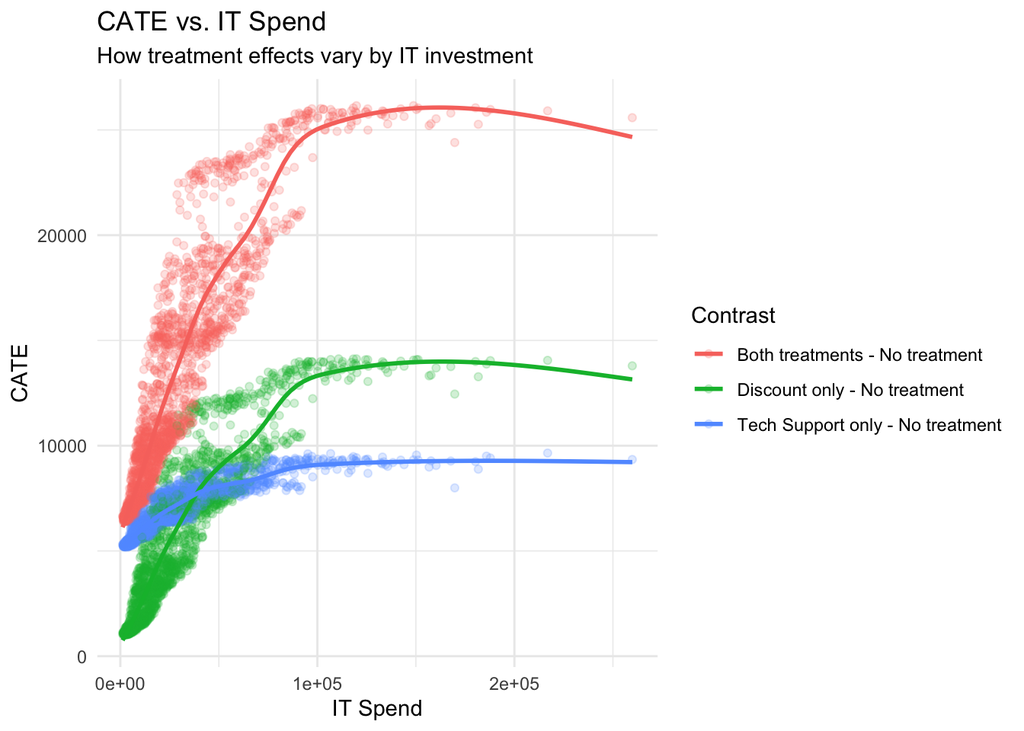

```r
plot_df <- cbind(df, as.data.frame(tau_hat))

plot_df_long <- plot_df %>%
  pivot_longer(cols = colnames(tau_hat),
               names_to = "Contrast",
               values_to = "CATE")

ggplot(plot_df_long, aes(x = IT.Spend, y = CATE, color = Contrast)) +
  geom_point(alpha = 0.2) +
  geom_smooth(method = "gam", se = FALSE,
              formula = y ~ s(x, bs = "cs", k = 40)) +
  theme_minimal() +
  labs(title = "CATE vs. IT Spend",
       subtitle = "How treatment effects vary by IT investment",
       x = "IT Spend",
       y = "CATE")
```

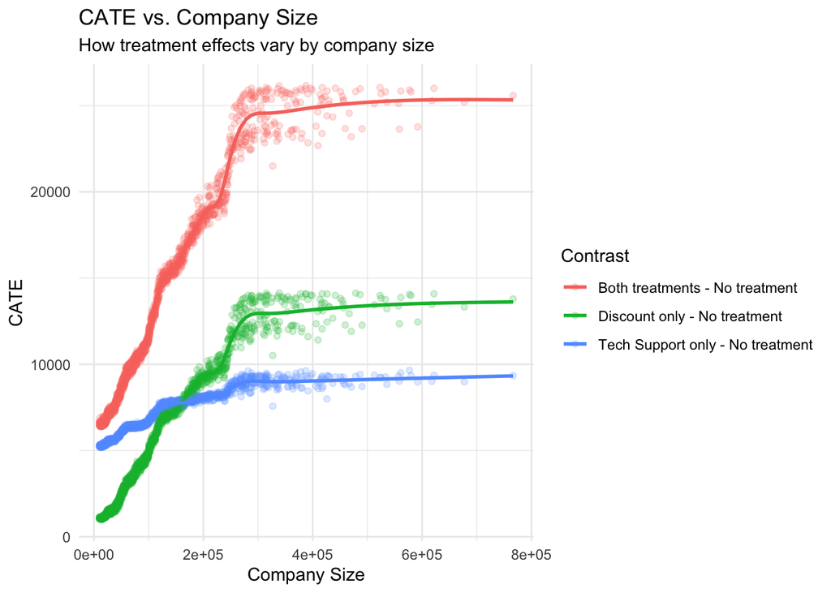

```r
ggplot(plot_df_long, aes(x = Size, y = CATE, color = Contrast)) +
  geom_point(alpha = 0.2) +
  geom_smooth(method = "gam", se = FALSE,
              formula = y ~ s(x, bs = "cs", k = 40)) +
  theme_minimal() +
  labs(title = "CATE vs. Company Size",
       subtitle = "How treatment effects vary by company size",
       x = "Company Size",
       y = "CATE")
```

# Treatment assignment optimization

There are several ways to exploit the causal forest model for decision-making. We consider a setting in which treatments have associated costs: offering a discount costs $6000, technical support costs $7000, so offering both treatments costs $13000. The no-treatment option has zero cost. The objective is to determine an optimal treatment allocation rule that maps covariates to treatments in order to maximize expected net revenue subject to a total budget constraint.

Under the observed assignment, the total cost of treatments in the data is $13,168,000.

Using the estimated CATEs, we assign treatments based on covariates to maximize expected net value. We define the unit-level net value of treatment $k$ as
$$\text{net}_k(X) = \tau_k(X) - c_k,$$
where $c_k$ denotes the cost of treatment $k$, and $\tau_k(X) = \mathbb{E}[Y(k) - Y(0)\mid X]$ is the conditional average treatment effect relative to the no-treatment baseline. Thus, $\text{net}_k(X)$ represents the expected incremental profit of assigning treatment $k$ to a unit with characteristics $X$.

The optimal assignment is then obtained by solving the constrained optimization problem:

$$\arg\max_{d_{ik}} \sum_{i=1}^n \sum_{k}
d_{ik}\,\text{net}_k(X_i),
\quad \text{s.t.} \quad \sum_k d_{ik} = 1,\ \sum_{i,k} d_{ik} c_k \le
B,$$

with $d_{ik}$ in $\{0,1\}$, which is a binary decision variable equal to 1 if unit $i$ is assigned to treatment $k$, and 0 otherwise. $B$ is the maximum total cost allowed.

```r
library(lpSolve)

# ----------------------------
# Costs
# ----------------------------

treatment_cost <- c(
  "No treatment" = 0,
  "Discount only" = 6000,
  "Tech Support only" = 7000,
  "Both treatments" = 13000
)

# ----------------------------
# Net value (tau - cost)
# ----------------------------

net_value <- cbind(
  "No treatment" = 0,
  "Discount only" = tau_hat[, "Discount only - No treatment"] - treatment_cost["Discount only"],
  "Tech Support only" = tau_hat[, "Tech Support only - No treatment"] - treatment_cost["Tech Support only"],
  "Both treatments" = tau_hat[, "Both treatments - No treatment"] - treatment_cost["Both treatments"]
)

n_units <- nrow(net_value)
n_treatments <- ncol(net_value)

colnames(net_value) <- names(treatment_cost)

# Objective vector (maximize total net value)
objective_vec <- as.vector(t(net_value))


# ----------------------------
# Constraints
# ----------------------------

# (A) each unit gets exactly one treatment
assignment_matrix <- matrix(0, nrow = n_units, ncol = n_units * n_treatments)

for (i in 1:n_units) {
  assignment_matrix[i, ((i - 1) * n_treatments + 1):(i * n_treatments)] <- 1
}

assignment_dir <- rep("=", n_units)
assignment_rhs <- rep(1, n_units)


# total budget constraint (from observed data)
budget_limit <- sum(
  (df$Discount == 1 & df$Tech.Support == 0) * 6000 +
  (df$Discount == 0 & df$Tech.Support == 1) * 7000 +
  (df$Discount == 1 & df$Tech.Support == 1) * 13000
)

cost_vector <- as.vector(t(matrix(rep(treatment_cost, each = n_units), nrow = n_units)))

budget_matrix <- matrix(cost_vector, nrow = 1)
budget_dir <- "<="
budget_rhs <- budget_limit


# ----------------------------
# Solve ILP
# ----------------------------

solution <- lp(
  direction = "max",
  objective.in = objective_vec,
  const.mat = rbind(assignment_matrix, budget_matrix),
  const.dir = c(assignment_dir, budget_dir),
  const.rhs = c(assignment_rhs, budget_rhs),
  all.bin = TRUE
)


# ----------------------------
# Extract policy
# ----------------------------

decision_matrix <- matrix(solution$solution, nrow = n_units, byrow = TRUE)
colnames(decision_matrix) <- names(treatment_cost)

optimal_policy <- colnames(decision_matrix)[max.col(decision_matrix)]


# ----------------------------
# Policy evaluation (net value)
# ----------------------------

selected_net_value <- net_value[
  cbind(1:n_units, match(optimal_policy, colnames(net_value)))
]

total_net_value_optimal <- sum(selected_net_value)


# ----------------------------
# Observed policy evaluation
# ----------------------------

get_net_value <- function(treatment, i) {

  if (treatment == "No treatment") return(0)

  tau_col <- paste0(treatment, " - No treatment")

  tau_hat[i, tau_col] - treatment_cost[treatment]
}

total_net_value_observed <- sum(
  sapply(1:nrow(df), function(i) {
    get_net_value(df$W[i], i)
  })
)


# ----------------------------
# Outputs
# ----------------------------

table(optimal_policy)
```

```
## optimal_policy
##   Both treatments      No treatment Tech Support only
##               752              1216                32
```

```r
total_net_value_optimal
```

```
## [1] 4380829
```

```r
total_net_value_observed
```

```
## [1] 1272546
```

```r
total_net_value_optimal - total_net_value_observed
```

```
## [1] 3108284
```

```r
total_net_value_optimal/total_net_value_observed
```

```
## [1] 3.442571
```